# Modeling and Prediction for Movies

## Setup

##### Load packages

```r
library(ggplot2)
library(tidyverse)
library(dplyr)
library(statsr)
library(GGally)
library(knitr)
library(viridis)
library(gridExtra)
library(car)
```

##### Load data

```r
load("movies.Rdata")
```

## Part 1: Data

The dataset contains more than 600 randomly sampled movies produced and released before 2016. The rates are from 2 popular movie review websites, Rotten Tomatoes and IMDB. The size of sampling is big enough for regression analysis. Random sampling ensures no bias for the analysis.

Obviously, the data is for an observational study and no causality can be gathered. We can only find some associations between the given variables. If we want to conduct a causal study, more experimental data is necessary.

## Part 2: Research question

**What variables are strongly associated with the movie ratings?**

Because movie ratings are an overall evaluation for a movie, which represents the audiences’ impressions to the movie. Meanwhile, the ratings may drive other audiences to choose watching the movie or not. Therefore, the movie ratings reflect the quality of a movie and influence the popularity of a movie.

## Part 3: Exploratory data analysis

##### Check data quality

First let’s see if there are repetitive movies in our dataset.

| title | studio | thtr_rel_year | runtime | director |
| --- | --- | --- | --- | --- |
| Hairspray | New Line Cinema | 2007 | 117 | Adam Shankman |
| Where the Heart Is | Touchstone Pictures | 1990 | 107 | John Boorman |
| Where the Heart Is | Twentieth Century Fox Home Entertainment | 2000 | 120 | Matt Williams |
| Man on Wire | Magnolia Pictures | 2008 | 94 | James Marsh |
| Maniac | Analysis | 1980 | 87 | William Lustig |
| Man on Wire | Magnolia Pictures | 2008 | 94 | James Marsh |
| Hairspray | New Line Home Entertainment | 1988 | 92 | John Waters |
| Maniac | IFC Midnight | 2013 | 89 | Franck Khalfoun |

Although 4 titles are repetitive, only movie Man on Wire is a repetitive data. Therefore, we remove that record.

Then, we check the NA values in our dataset.

```r
summary(movies)
```

- `runtime`: 1 NA
- `studio`: 8 NAs
- `dvd_rel_year`: 8 NAs
- `dvd_rel_month`: 8 NAs
- `dvd_rel_day`: 8 NAs

```r
movies <- movies[!is.na(movies['runtime']), ]
```

##### Data Visualization and Exploration

In our dataset, there are three numerical ratings for movies coming from different platforms and different types of audiences.

`imdb_rating`: Rating on IMDB (0-10 scale)

`critics_score`: Critics score on Rotten Tomatoes (0-100 scale)

`audience_score`: Audience score on Rotten Tomatoes (0-100 scale)

For convinience, we unify the scales for ratings from different platform. Change the 0-10 scale of ratings on IMDB to 0-100 scale.

```r
movies['imdb_rating'] <- movies['imdb_rating'] * 10
```

Then we have a look at the correlation between these three ratings

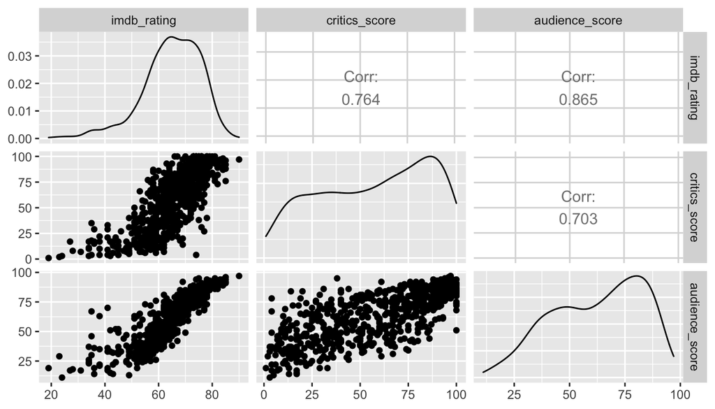

```r
ggpairs(movies, columns = c(13,16,18))
```

From the plots, we observe that these three scores are highly positively correlated. It is possible that that we construct an average rating based on the three ratings.

```r
movies <- movies %>%
  mutate(avg_score = (imdb_rating + critics_score + audience_score)/3 )
```

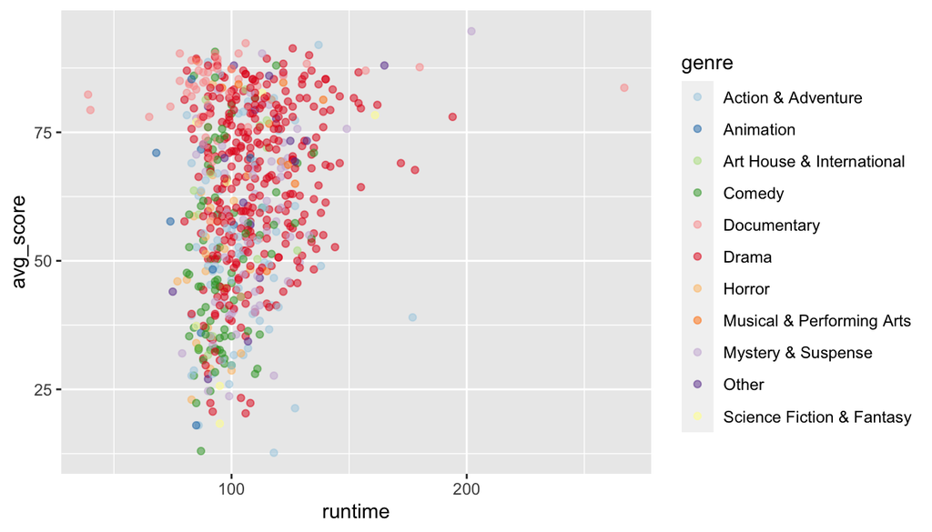

```r
p2<-ggplot(movies, aes(x=runtime, y=avg_score, color=genre)) +
  geom_point(alpha=0.5) +
  scale_color_brewer(palette="Paired")
p2
```

Runtime of most movies is around 100 minutes. The linear relationship bwteeen runtime and average score is not obvious. From the plot, the score distributions for different genre are hard to find.

```r
kable(summary(movies$genre))
```

|  | x |
| --- | --- |
| Action & Adventure | 65 |
| Animation | 9 |
| Art House & International | 14 |
| Comedy | 87 |
| Documentary | 50 |
| Drama | 305 |
| Horror | 23 |
| Musical & Performing Arts | 12 |
| Mystery & Suspense | 59 |
| Other | 16 |
| Science Fiction & Fantasy | 9 |

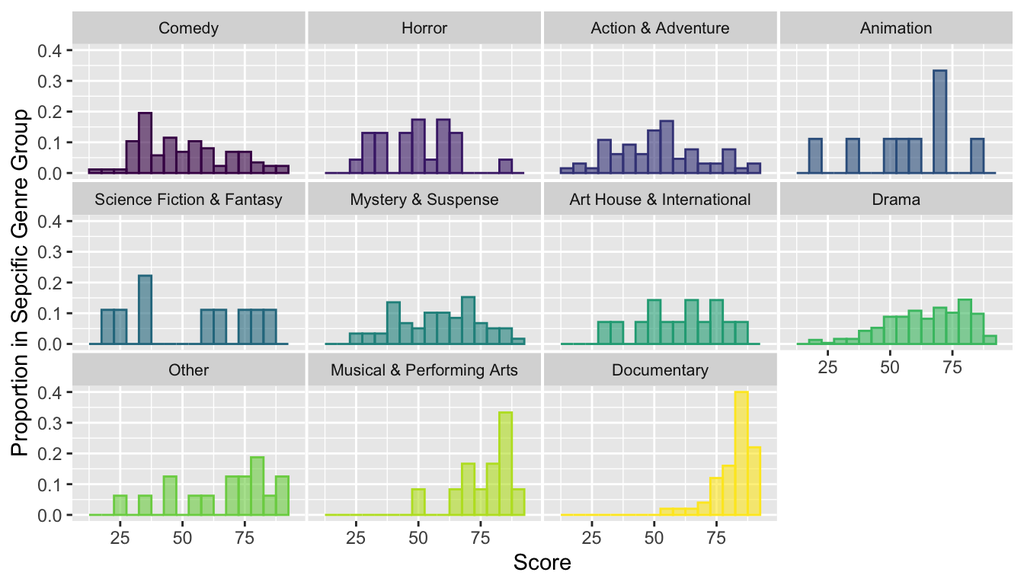

```r
movies %>%
  mutate(genre = fct_reorder(genre, avg_score)) %>%
  group_by(genre) %>%
  mutate(weight = 1 / n()) %>%
  ggplot(aes(x=avg_score, color=genre, fill=genre)) +
  geom_histogram(aes(weight = weight), alpha=0.6, binwidth = 5) +
  scale_fill_viridis(discrete=TRUE) +
  scale_color_viridis(discrete=TRUE) +
  theme(
    legend.position="none",
    panel.spacing = unit(0.1, "lines"),
    strip.text.x = element_text(size = 8)
  ) +
  xlab("Score") +
  ylab("Proportion in Sepcific Genre Group") +
  xlim(10, 95) +
  facet_wrap(~genre)
```

```r
kable(summary(movies$mpaa_rating))
```

|  | x |
| --- | --- |
| G | 19 |
| NC-17 | 2 |
| PG | 118 |
| PG-13 | 132 |
| R | 329 |
| Unrated | 49 |

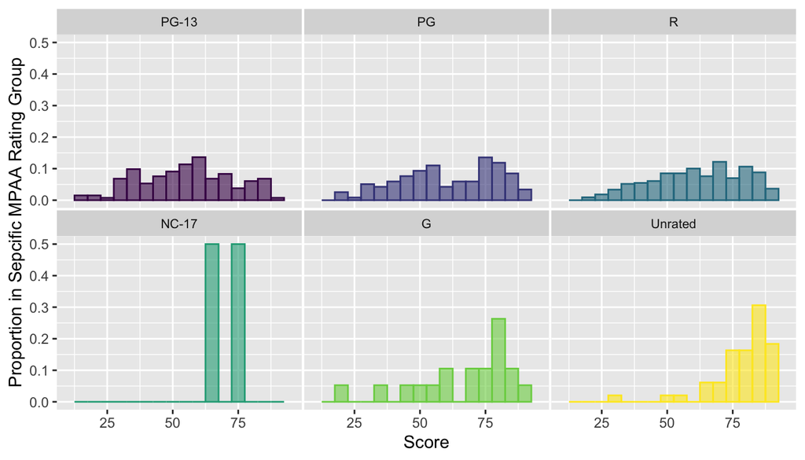

```r
movies %>%
  mutate(mpaa_rating = fct_reorder(mpaa_rating, avg_score)) %>%
  group_by(mpaa_rating) %>%
  mutate(weight = 1 / n()) %>%
  ggplot(aes(x=avg_score, color=mpaa_rating, fill=mpaa_rating)) +
  geom_histogram(aes(weight = weight), alpha=0.6, binwidth = 5) +
  scale_fill_viridis(discrete=TRUE) +
  scale_color_viridis(discrete=TRUE) +
  theme(
    legend.position="none",
    panel.spacing = unit(0.1, "lines"),
    strip.text.x = element_text(size = 8)
  ) +
  xlab("Score") +
  ylab("Proportion in Sepcific MPAA Rating Group") +
  xlim(10, 95) +
  facet_wrap(~mpaa_rating)
```

From the plot, we can observe that the rating distributions are dissimilar for different MPAA ratings. The ratings of PG-13 movies most distribute from 30 to 90 and ratings between 50-65 is a large proportion. The ratings of PG movies has 2 peaks around 55 and 75 score. Ratings of R movies are left skewed distributed. NC-17 movies have very little samples. Ratings of G and unrated movies are extremely left skewed distributed. Among the samples, the sum of numbers of NC-17, G and unrated movies is 70, which is a small part in the samples.

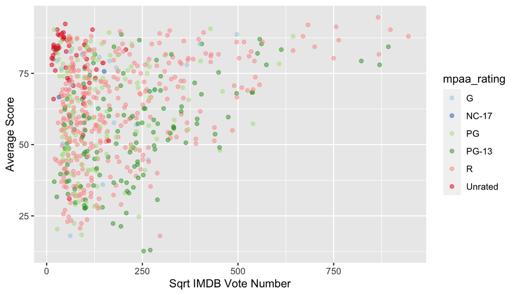

```r
movies %>%
  ggplot(aes(sqrt(imdb_num_votes), avg_score, color=mpaa_rating)) +
  geom_point(alpha=0.5) +
  scale_color_brewer(palette="Paired") +
  xlab("Sqrt IMDB Vote Number") +
  ylab("Average Score")
```

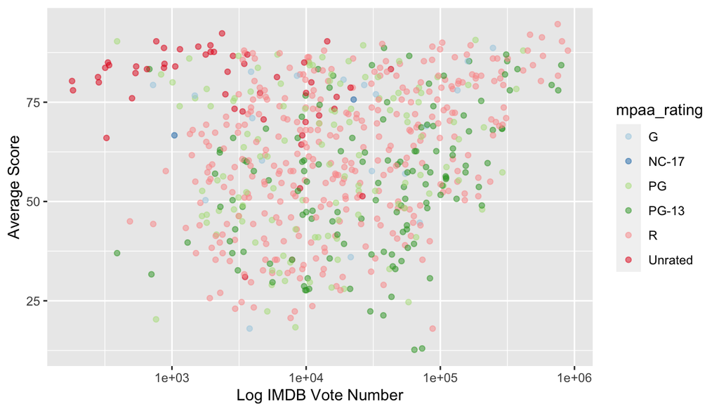

```r
movies %>%
  ggplot(aes(imdb_num_votes, avg_score, color=mpaa_rating)) +
  scale_x_log10() +
  geom_point(alpha=0.5) +
  scale_color_brewer(palette="Paired") +
  xlab("Log IMDB Vote Number") +
  ylab("Average Score")
```

The range of imdb vote number is wide, so we use log scale and square root for x axis. For movies with some mpaa_ratings (i.e. PG-13, R), we can observe some kind of linear relationship between average score and log (square root) IMDB vote number.

A lot of movie studios are in our dataset. Some of them are famous and produced many movies. Let’s check the studio which produced more than 15 movies.

```r
kable(summary(movies$studio)[summary(movies$studio) > 15])
```

|  | x |
| --- | --- |
| Paramount Pictures | 37 |
| Warner Bros. Pictures | 30 |
| Sony Pictures Home Entertainment | 27 |
| Universal Pictures | 23 |
| Warner Home Video | 19 |
| 20th Century Fox | 18 |
| Miramax Films | 18 |
| MGM | 16 |
| (Other) | 112 |

```r
studio_name <- names(summary(movies$studio))[which(summary(movies$studio) > 15)]
studio_name <- studio_name[-which(studio_name=='(Other)')]

movies <- movies %>%
  mutate(studio = as.character(studio)) %>%
  mutate(studio_trans = ifelse(studio %in% studio_name, 1, 0))
```

## Part 4: Modeling

##### Model Building and Model Selection

First, we build model with orginal data. The model statistically significant with F-statistic=17.29 (df$_1$=25, df$_2$=623). The residual standard error is 14.28. Some variables are not statistically significant and the R$^2$ and adjusted R$^2$ are only 0.4097 and 0.386 respectively. The model explains only 40.97% variability of the response variable.

```r
# The full model
m0 <- lm(data = movies, avg_score ~ runtime + imdb_num_votes + title_type +
           mpaa_rating + genre + best_pic_nom + best_pic_win +
           best_dir_win + best_actor_win + best_actress_win +
           top200_box)

summary(m0)
```

```
##
## Call:
## lm(formula = avg_score ~ runtime + imdb_num_votes + title_type +
##     mpaa_rating + genre + best_pic_nom + best_pic_win + best_dir_win +
##     best_actor_win + best_actress_win + top200_box, data = movies)
##
## Residuals:
##     Min      1Q  Median      3Q     Max
## -42.670  -9.415   0.582  10.270  36.435
##
## Coefficients:
##                                  Estimate Std. Error t value Pr(>|t|)
## (Intercept)                     6.940e+01  7.257e+00   9.564  < 2e-16 ***
## runtime                         6.109e-02  3.490e-02   1.750 0.080573 .
## imdb_num_votes                  4.793e-05  5.986e-06   8.006 5.81e-15 ***
## title_typeFeature Film         -1.716e+01  5.300e+00  -3.238 0.001268 **
## title_typeTV Movie             -2.162e+01  8.340e+00  -2.593 0.009749 **
## mpaa_ratingNC-17               -1.193e+00  1.085e+01  -0.110 0.912493
## mpaa_ratingPG                  -9.469e+00  3.941e+00  -2.402 0.016577 *
## mpaa_ratingPG-13               -1.745e+01  4.043e+00  -4.316 1.85e-05 ***
## mpaa_ratingR                   -1.103e+01  3.925e+00  -2.809 0.005121 **
## mpaa_ratingUnrated             -3.427e+00  4.520e+00  -0.758 0.448580
## genreAnimation                  1.929e-01  5.608e+00   0.034 0.972577
## genreArt House & International  1.092e+01  4.338e+00   2.518 0.012049 *
## genreComedy                     2.144e+00  2.404e+00   0.892 0.372870
## genreDocumentary                1.322e+01  5.699e+00   2.319 0.020712 *
## genreDrama                      1.372e+01  2.053e+00   6.682 5.23e-11 ***
## genreHorror                    -7.508e-02  3.574e+00  -0.021 0.983244
## genreMusical & Performing Arts  1.993e+01  4.863e+00   4.097 4.73e-05 ***
## genreMystery & Suspense         6.821e+00  2.674e+00   2.551 0.010987 *
## genreOther                      1.002e+01  4.062e+00   2.468 0.013863 *
## genreScience Fiction & Fantasy -8.012e-01  5.092e+00  -0.157 0.875023
## best_pic_nomyes                 1.244e+01  3.724e+00   3.340 0.000887 ***
## best_pic_winyes                -1.078e+01  6.615e+00  -1.630 0.103677
## best_dir_winyes                 6.188e+00  2.456e+00   2.519 0.012012 *
## best_actor_winyes              -5.519e-01  1.705e+00  -0.324 0.746346
## best_actress_winyes            -4.545e-01  1.887e+00  -0.241 0.809700
## top200_boxyes                   3.593e+00  4.004e+00   0.897 0.369864
## ---
## Signif. codes:  0 '***' 0.001 '**' 0.01 '*' 0.05 '.' 0.1 ' ' 1
##
## Residual standard error: 14.28 on 623 degrees of freedom
## Multiple R-squared:  0.4097, Adjusted R-squared:  0.386
## F-statistic: 17.29 on 25 and 623 DF,  p-value: < 2.2e-16
```

If we add the created viariable with studio infomation and change the scale of `runtime` and `imdb_num_votes`, the R$^2$ and adjusted R$^2$ are slightly improved.

```r
# Add created studio infomation
m1 <- lm(data = movies, avg_score ~ log(runtime) + sqrt(imdb_num_votes) +
           title_type + studio_trans +
           mpaa_rating + genre + best_pic_nom + best_pic_win +
           best_dir_win + best_actor_win + best_actress_win +
           top200_box)

summary(m1)
```

```
##
## Call:
## lm(formula = avg_score ~ log(runtime) + sqrt(imdb_num_votes) +
##     title_type + studio_trans + mpaa_rating + genre + best_pic_nom +
##     best_pic_win + best_dir_win + best_actor_win + best_actress_win +
##     top200_box, data = movies)
##
## Residuals:
##     Min      1Q  Median      3Q     Max
## -40.618  -9.089   0.340   9.317  35.166
##
## Coefficients:
##                                  Estimate Std. Error t value Pr(>|t|)
## (Intercept)                     36.530003  18.243305   2.002 0.045678 *
## log(runtime)                     7.796704   3.841007   2.030 0.042796 *
## sqrt(imdb_num_votes)             0.042843   0.004198  10.207  < 2e-16 ***
## title_typeFeature Film         -19.534983   5.148082  -3.795 0.000162 ***
## title_typeTV Movie             -22.790518   8.092673  -2.816 0.005014 **
## studio_trans                    -3.702967   1.300157  -2.848 0.004544 **
## mpaa_ratingNC-17                 0.101985  10.527951   0.010 0.992274
## mpaa_ratingPG                   -8.339154   3.862771  -2.159 0.031243 *
## mpaa_ratingPG-13               -17.316714   3.970541  -4.361 1.51e-05 ***
## mpaa_ratingR                   -10.594707   3.839599  -2.759 0.005963 **
## mpaa_ratingUnrated              -2.676856   4.400297  -0.608 0.543187
## genreAnimation                   1.333011   5.469898   0.244 0.807544
## genreArt House & International  13.178102   4.233237   3.113 0.001937 **
## genreComedy                      3.478356   2.341369   1.486 0.137890
## genreDocumentary                14.129445   5.546908   2.547 0.011097 *
## genreDrama                      14.719466   2.011653   7.317 7.85e-13 ***
## genreHorror                      1.275535   3.476763   0.367 0.713838
## genreMusical & Performing Arts  20.037224   4.741921   4.226 2.74e-05 ***
## genreMystery & Suspense          7.573511   2.600404   2.912 0.003715 **
## genreOther                      11.348816   3.943243   2.878 0.004139 **
## genreScience Fiction & Fantasy   0.325597   4.941332   0.066 0.947485
## best_pic_nomyes                 11.642162   3.604606   3.230 0.001304 **
## best_pic_winyes                 -9.688898   6.374262  -1.520 0.129018
## best_dir_winyes                  5.797354   2.385739   2.430 0.015381 *
## best_actor_winyes               -0.705791   1.661441  -0.425 0.671125
## best_actress_winyes             -0.325995   1.831832  -0.178 0.858811
## top200_boxyes                    3.029183   3.879747   0.781 0.435236
## ---
## Signif. codes:  0 '***' 0.001 '**' 0.01 '*' 0.05 '.' 0.1 ' ' 1
##
## Residual standard error: 13.85 on 622 degrees of freedom
## Multiple R-squared:  0.4453, Adjusted R-squared:  0.4222
## F-statistic: 19.21 on 26 and 622 DF,  p-value: < 2.2e-16
```

```r
m2 <- step(m1, direction = "both" , trace = FALSE)
summary(m2)
```

```
##
## Call:
## lm(formula = avg_score ~ log(runtime) + sqrt(imdb_num_votes) +
##     title_type + studio_trans + mpaa_rating + genre + best_pic_nom +
##     best_pic_win + best_dir_win, data = movies)
##
## Residuals:
##     Min      1Q  Median      3Q     Max
## -40.506  -9.095   0.302   9.403  35.244
##
## Coefficients:
##                                  Estimate Std. Error t value Pr(>|t|)
## (Intercept)                     37.823279  17.828465   2.122 0.034272 *
## log(runtime)                     7.595557   3.742159   2.030 0.042808 *
## sqrt(imdb_num_votes)             0.043626   0.004075  10.706  < 2e-16 ***
## title_typeFeature Film         -19.592181   5.138493  -3.813 0.000151 ***
## title_typeTV Movie             -22.767652   8.074767  -2.820 0.004961 **
## studio_trans                    -3.701099   1.287946  -2.874 0.004195 **
## mpaa_ratingNC-17                -0.470430  10.477983  -0.045 0.964204
## mpaa_ratingPG                   -8.636388   3.839001  -2.250 0.024819 *
## mpaa_ratingPG-13               -17.704271   3.928211  -4.507 7.85e-06 ***
## mpaa_ratingR                   -10.988419   3.792208  -2.898 0.003892 **
## mpaa_ratingUnrated              -2.977650   4.368421  -0.682 0.495725
## genreAnimation                   0.811603   5.423292   0.150 0.881088
## genreArt House & International  13.141194   4.219520   3.114 0.001928 **
## genreComedy                      3.331873   2.323392   1.434 0.152056
## genreDocumentary                13.973409   5.532980   2.525 0.011800 *
## genreDrama                      14.554824   1.986842   7.326 7.37e-13 ***
## genreHorror                      1.219178   3.467674   0.352 0.725269
## genreMusical & Performing Arts  19.937188   4.731262   4.214 2.88e-05 ***
## genreMystery & Suspense          7.306687   2.563538   2.850 0.004513 **
## genreOther                      11.267241   3.932794   2.865 0.004311 **
## genreScience Fiction & Fantasy   0.507215   4.927745   0.103 0.918051
## best_pic_nomyes                 11.358846   3.554490   3.196 0.001466 **
## best_pic_winyes                 -9.482550   6.337396  -1.496 0.135084
## best_dir_winyes                  5.698924   2.378408   2.396 0.016863 *
## ---
## Signif. codes:  0 '***' 0.001 '**' 0.01 '*' 0.05 '.' 0.1 ' ' 1
##
## Residual standard error: 13.83 on 625 degrees of freedom
## Multiple R-squared:  0.4446, Adjusted R-squared:  0.4242
## F-statistic: 21.75 on 23 and 625 DF,  p-value: < 2.2e-16
```

```r
m3 <- lm(data = movies, avg_score ~ log(runtime) + sqrt(imdb_num_votes) +
           title_type + studio_trans +
           mpaa_rating + genre + best_pic_nom +
           best_dir_win)

summary(m3)
```

```
##
## Call:
## lm(formula = avg_score ~ log(runtime) + sqrt(imdb_num_votes) +
##     title_type + studio_trans + mpaa_rating + genre + best_pic_nom +
##     best_dir_win, data = movies)
##
## Residuals:
##     Min      1Q  Median      3Q     Max
## -40.556  -8.938   0.457   9.694  35.299
##
## Coefficients:
##                                  Estimate Std. Error t value Pr(>|t|)
## (Intercept)                     37.683439  17.845852   2.112 0.035116 *
## log(runtime)                     7.653117   3.745662   2.043 0.041451 *
## sqrt(imdb_num_votes)             0.042804   0.004042  10.591  < 2e-16 ***
## title_typeFeature Film         -19.521333   5.143357  -3.795 0.000162 ***
## title_typeTV Movie             -22.873210   8.082444  -2.830 0.004804 **
## studio_trans                    -3.651282   1.288789  -2.833 0.004758 **
## mpaa_ratingNC-17                -0.528177  10.488275  -0.050 0.959853
## mpaa_ratingPG                   -8.666021   3.842747  -2.255 0.024468 *
## mpaa_ratingPG-13               -17.574682   3.931141  -4.471 9.26e-06 ***
## mpaa_ratingR                   -10.937959   3.795809  -2.882 0.004092 **
## mpaa_ratingUnrated              -2.998973   4.372718  -0.686 0.493070
## genreAnimation                   0.780176   5.428615   0.144 0.885771
## genreArt House & International  12.976749   4.222260   3.073 0.002208 **
## genreComedy                      3.163449   2.322959   1.362 0.173745
## genreDocumentary                13.895851   5.538209   2.509 0.012356 *
## genreDrama                      14.492370   1.988368   7.289 9.48e-13 ***
## genreHorror                      1.136857   3.470666   0.328 0.743353
## genreMusical & Performing Arts  19.914407   4.735917   4.205 2.99e-05 ***
## genreMystery & Suspense          7.228137   2.565535   2.817 0.004994 **
## genreOther                      11.579237   3.931147   2.946 0.003344 **
## genreScience Fiction & Fantasy   0.557475   4.932504   0.113 0.910050
## best_pic_nomyes                  9.143748   3.234731   2.827 0.004853 **
## best_dir_winyes                  4.707021   2.286416   2.059 0.039937 *
## ---
## Signif. codes:  0 '***' 0.001 '**' 0.01 '*' 0.05 '.' 0.1 ' ' 1
##
## Residual standard error: 13.84 on 626 degrees of freedom
## Multiple R-squared:  0.4426, Adjusted R-squared:  0.423
## F-statistic:  22.6 on 22 and 626 DF,  p-value: < 2.2e-16
```

##### Model Diagnostics

- Linear relationship
- Multivariate normality
- No or little multicollinearity
- No auto-correlation
- Homoscedasticity

Check multicollinearity: The variance inflation factor (after adjusting degree of freedom) is around 1, which shows weak multicollinearity in our model.

```r
vif(m3)
```

```
##                           GVIF Df GVIF^(1/(2*Df))
## log(runtime)          1.423939  1        1.193289
## sqrt(imdb_num_votes)  1.394383  1        1.180840
## title_type            7.041215  2        1.628966
## studio_trans          1.157345  1        1.075800
## mpaa_rating           2.647020  5        1.102239
## genre                12.699159 10        1.135504
## best_pic_nom          1.160399  1        1.077218
## best_dir_win          1.095197  1        1.046517
```

Residuals are randomly around 0 and do not show obvious shape. The residuals are basically normally distributed and there is a little curve in the Q-Q plot in the top and bottom but can be accepted.

Due to random sampling, the residuals are independent.

Therefore, the linear regression model satisfies the model assumptions.

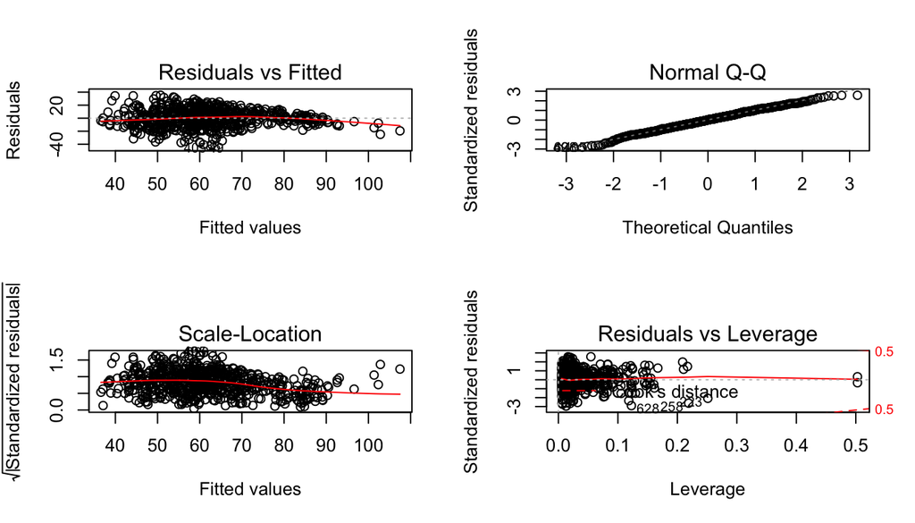

```r
par(mfrow = c(2, 2))
plot(m3)
```

[figure not shown]

```r
hist(m3$residuals , col = "steelblue" ,breaks = 25, main = "residuals distribution" , xlab = "residuals" )
```

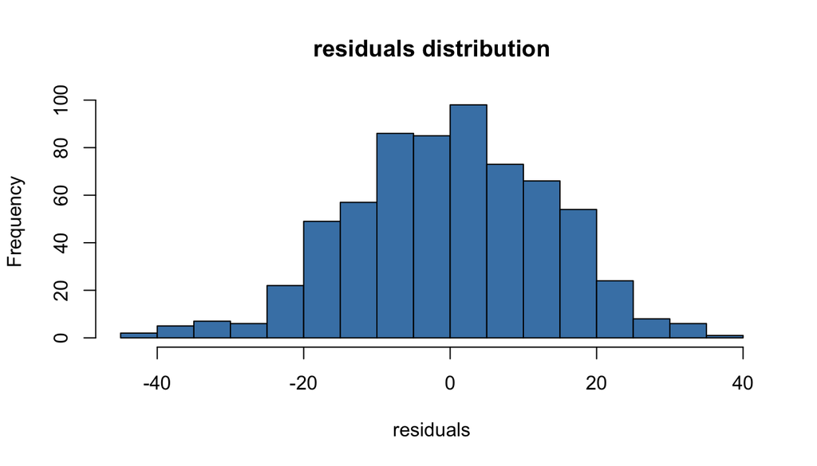

```r
hist(m3$residuals , col = "steelblue" ,breaks = 25, main = "residuals distribution" , xlab = "residuals" )
```

## Part 5: Prediction

##### Predict a 2019 movie Us(2019)

```r
predicted_movie <- data.frame(runtime = 116,
                              imdb_num_votes = 186995,
                              mpaa_rating = "R" ,
                              genre = "Mystery & Suspense",
                              title_type = "Feature Film",
                              studio_trans = 1,
                              best_pic_nom = "no",
                              best_dir_win = "no")
predict(m3 , predicted_movie , interval = "prediction" , level = 0.95 )
```

```
##        fit    lwr      upr
## 1 65.69045 38.174 93.20691
```

The score of the movie:

- IMDb: 6.9
- RT_critics: 93
- RT_audiences: 59
- **Average score: 73.6**
- **Predicted average score: 65.7** (Falls between the confidence interval and 8 lower than the actual value)

##### Predict a 2017 movie War for the Planet of the Apes

```r
predicted_movie <- data.frame(runtime = 140,
                              imdb_num_votes = 214141,
                              mpaa_rating = "PG-13" ,
                              genre = "Drama",
                              title_type = "Feature Film",
                              studio_trans = 1,
                              best_pic_nom = "no",
                              best_dir_win = "no")
predict(m3 , predicted_movie , interval = "prediction" , level = 0.95 )
```

```
##        fit      lwr      upr
## 1 69.05516 41.61403 96.49629
```

The score of the movie:

- IMDb: 7.4
- RT_critics: 94
- RT_audiences: 84
- **Average score: 84**
- **Predicted average score: 69.1** (Falls between the confidence interval and 15 lower than the actual value)

##### Predict a 2019 movie Joker

```r
predicted_movie <- data.frame(runtime = 122,
                              imdb_num_votes = 710243,
                              mpaa_rating = "R" ,
                              genre = "Action & Adventure",
                              title_type = "Feature Film",
                              studio_trans = 1,
                              best_pic_nom = "yes",
                              best_dir_win = "no")
predict(m3 , predicted_movie , interval = "prediction" , level = 0.95 )
```

```
##        fit      lwr      upr
## 1 85.55576 57.28263 113.8289
```

The score of the movie:

- IMDb: 8.6
- RT_critics: 68
- RT_audiences: 88
- **Average score: 80.66**
- **Predicted average score: 85.6** (Falls between the confidence interval and 5 higher than the actual value)

## Part 6: Conclusion

In this linear regression case, we explore the sample data by visualizing and build a regression model to predict the score for a movie. For our dataset, we lack data for some specific genre and MMPA rating. Meanwhile, most of our available exploratary variables are categorical, which is relatively hard to build a perfect regression model. In the prediction part, we use three movies after 2016 to test the prediction result. All the prediction results are in the 95% confidence interval.